# Reproducible Research: Peer Assessment 1

Jennifer Mollon

14 February 2015

## Loading and preprocessing the data

Unzip and read in data, and take a look at the structure. The unzip step is commented out, as this only needs to be done the first time the script is run. From then on it just needs to be loaded from the local file.

```r
#unzip ("activity.zip")
dat=read.csv("activity.csv")
```

The structure is a 3-column data frame, with column names steps, date, interval. There are 17568 entries (rows). Reformat the date, and investigate the data

```r
dat$date=as.Date(dat$date)
head(dat)
```

```
##   steps       date interval
## 1    NA 2012-10-01        0
## 2    NA 2012-10-01        5
## 3    NA 2012-10-01       10
## 4    NA 2012-10-01       15
## 5    NA 2012-10-01       20
## 6    NA 2012-10-01       25
```

```r
sum(is.na(dat))
```

```
## [1] 2304
```

```r
summary(dat)
```

```
##      steps             date               interval
##  Min.   :  0.00   Min.   :2012-10-01   Min.   :   0.0
##  1st Qu.:  0.00   1st Qu.:2012-10-16   1st Qu.: 588.8
##  Median :  0.00   Median :2012-10-31   Median :1177.5
##  Mean   : 37.38   Mean   :2012-10-31   Mean   :1177.5
##  3rd Qu.: 12.00   3rd Qu.:2012-11-15   3rd Qu.:1766.2
##  Max.   :806.00   Max.   :2012-11-30   Max.   :2355.0
##  NA's   :2304
```

```r
length(unique(dat$date))
```

```
## [1] 61
```

```r
length(unique(dat$steps))
```

```
## [1] 618
```

```r
length(unique(dat$interval))
```

```
## [1] 288
```

## What is mean total number of steps taken per day?

For this part of the assignment, we are told we can ignore missing data. I will remove it from my data frame and work with this for this section.

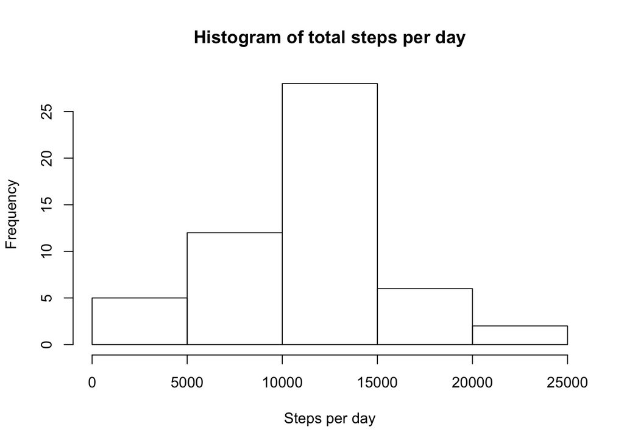

```r
dat_no_na=na.omit(dat)
total_steps_per_day=aggregate(dat_no_na$steps,by=list(dat_no_na$date),FUN=sum) #sum steps over days
hist(total_steps_per_day$x,main="Histogram of total steps per day",xlab="Steps per day") #plots steps per day
```

```r
mean_steps_per_day=mean(total_steps_per_day$x) #calculate mean steps per day
median_steps_per_day=median(total_steps_per_day$x) #calculate median steps per day
```

The mean and median steps per day are 10766.19 and 10765, respectively.

## What is the average daily activity pattern?

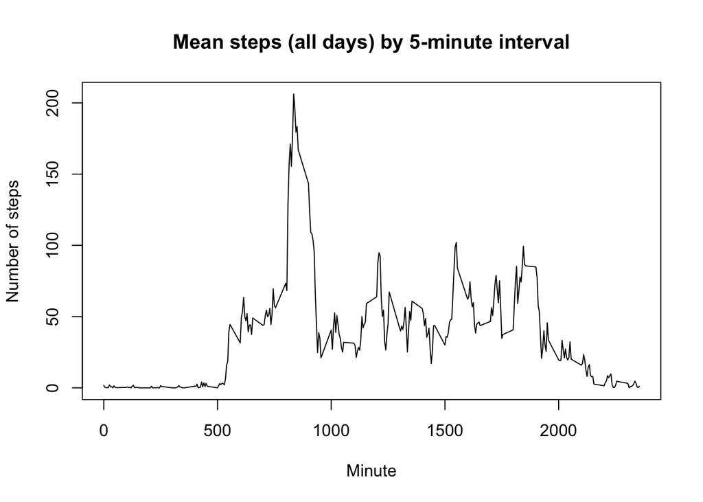

```r
steps_by_interval=aggregate(dat_no_na$steps,by=list(dat_no_na$interval),FUN=mean) #calculate mean steps by interval across all days
names(steps_by_interval)=c("Interval","Steps") #name columns in resulting data frame
plot(steps_by_interval,type="l",main="Mean steps (all days) by 5-minute interval",xlab="Minute",ylab="Number of steps") #plot time series
```

```r
max_steps_interval=steps_by_interval[which.max(steps_by_interval$Steps),] #find interval with maximum steps averaged across days
#find the hours and minutes for the start and end of that interval
interval_start_hour=(max_steps_interval$Interval)%/%60
interval_start_minute=(max_steps_interval$Interval)%%60
interval_end_hour=(max_steps_interval$Interval+5)%/%60
interval_end_minute=(max_steps_interval$Interval+5)%%60
#load string formatting library, then concatenate and format the start and end times
library(stringr)
start=paste(interval_start_hour,":",str_pad(interval_end_minute, 2, pad = "0"),sep="")
end=paste(interval_end_hour,":",str_pad(interval_end_minute, 2, pad = "0"),sep="")
```

## Imputing missing values

```r
#This checks for 'any' NAs in each row, then sums those values to get the number of rows with any missing elements
nrows_with_NAs=sum(apply(dat,1,FUN=function(x){any(is.na(x))}))
#Check if all missing values are in first column (e.g. steps)
apply(dat,2,FUN=function(x){any(is.na(x))})
```

```
##    steps     date interval
##     TRUE    FALSE    FALSE
```

There are a total of 2304 rows with NA values, all in the first column (steps). Replace the NAs with the mean for that 5-minute interval On the left of the ‘<-’, identify the positions (row number) with the missing values On the right, get the interval value from these row numbers and find the row number of the matching interval value in steps_by_intervals, returning the mean number of steps for that interval

```r
dat_fill_in_missing=dat #Make a copy of the original, to fill in missing values
#now identify missing data and fill in with mean for that value's interval
dat_fill_in_missing$steps[is.na(dat_fill_in_missing$steps)]<-steps_by_interval$Steps[match(dat_fill_in_missing$interval[is.na(dat_fill_in_missing$steps)],steps_by_interval$Interval)]
```

Now recreate the histogram and recalculate the mean and median as above, but with the missing data filled in with the interval mean.

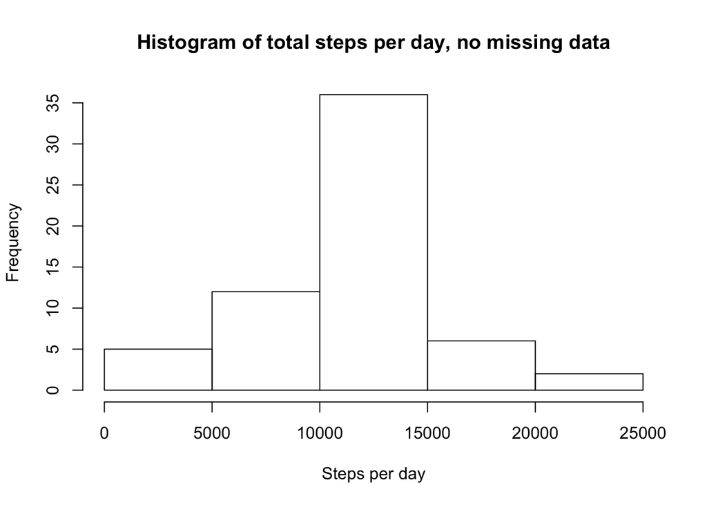

```r
#recalculate steps per day from the data with no missing values and plot
total_steps_per_day_no_missing=aggregate(dat_fill_in_missing$steps,by=list(dat_fill_in_missing$date),FUN=sum)
hist(total_steps_per_day_no_missing$x,main="Histogram of total steps per day, no missing data",xlab="Steps per day")
```

```r
#calculate mean and median steps per day from data with no missing values
mean_steps_per_day_no_missing=mean(total_steps_per_day_no_missing$x)
median_steps_per_day_no_missing=median(total_steps_per_day_no_missing$x)
```

The mean steps per day with missing values, and with missing values replaced by the interval’s mean, are both 10766.19. As expected, the overall mean does not change when missing values are replaced by the mean. However the median value does change, from 10765 to the mean value of 10766.19. This is because all of the relaced missing values are now clustered in the middle of the data distribution. One of these mean values in the centre of the distribution therefore becomes the new median.

## Are there differences in activity patterns between weekdays and weekends?

First create a column in the data frame to hold the factor ‘day_type’, with the value ‘weekend’ for Saturday and Sunday, and ‘weekday’ for all other days.

```r
#create empty vector to hold values of 'day_type', which can be weekday or weekend
dat_fill_in_missing$day_type=vector("character",length=length(dat_fill_in_missing$date))
#check if the name of the day is in the set ("Saturday","Sunday"). If yes, assign the value "weekend" to day_type, otherwise assign "weekday"
dat_fill_in_missing$day_type[weekdays(dat_fill_in_missing$date) %in% c("Saturday","Sunday")] = "weekend"
dat_fill_in_missing$day_type[!weekdays(dat_fill_in_missing$date) %in% c("Saturday","Sunday")] = "weekday"
#convert the character vector to a factor
dat_fill_in_missing$day_type=as.factor(dat_fill_in_missing$day_type)
```

```r
#calcualte mean steps per interval separately for weekdays and weekends
steps_by_interval_weekdays=aggregate(dat_fill_in_missing$steps[dat_fill_in_missing$day_type=="weekday"],by=list(dat_fill_in_missing$interval[dat_fill_in_missing$day_type=="weekday"]),FUN=mean)
steps_by_interval_weekends=aggregate(dat_fill_in_missing$steps[dat_fill_in_missing$day_type=="weekend"],by=list(dat_fill_in_missing$interval[dat_fill_in_missing$day_type=="weekend"]),FUN=mean)
#assign column names to each resulting data frame
names(steps_by_interval_weekdays)=c("Interval","Steps")
names(steps_by_interval_weekends)=c("Interval","Steps")
```

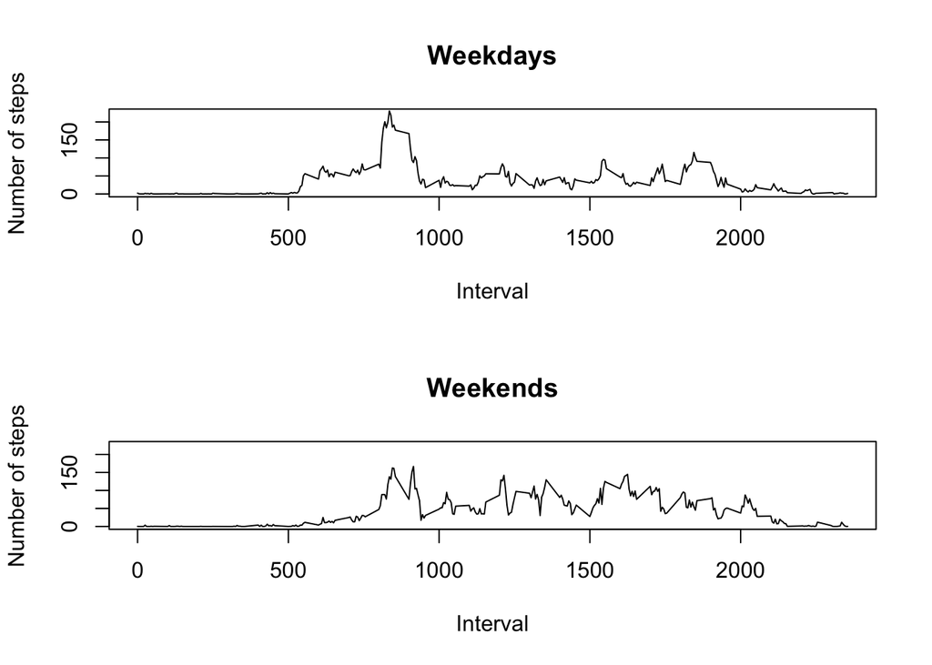

```r
#set the layout to get the 2 plots together, one above the other (e.g. in 2 rows, 1 column)
par(mfrow=c(2,1))
#find max value of the mean steps by interval and use it to create the range limits for the y-axis
y_range=c(1,1.1*(max(steps_by_interval[,2])))
#plot a times series for mean steps per interval for weekdays and weekends
plot(steps_by_interval_weekdays,type="l",main="Weekdays",xlab="Interval",ylab="Number of steps",ylim=y_range)
plot(steps_by_interval_weekends,type="l",main="Weekends",xlab="Interval",ylab="Number of steps",ylim=y_range)
```